# Artificial Intelligence Engineer Nanodegree - Probabilistic Models

## Project: Sign Language Recognition System

- Introduction
- Part 1 Feature Selection
  - Tutorial
  - Features Submission
  - Features Unittest
- Part 2 Train the models
  - Tutorial
  - Model Selection Score Submission
  - Model Score Unittest
- Part 3 Build a Recognizer
  - Tutorial
  - Recognizer Submission
  - Recognizer Unittest
- Part 4 (OPTIONAL) Improve the WER with Language Models

## Introduction

The overall goal of this project is to build a word recognizer for American Sign Language video sequences, demonstrating the power of probabalistic models. In particular, this project employs [hidden Markov models (HMM's)](https://en.wikipedia.org/wiki/Hidden_Markov_model) to analyze a series of measurements taken from videos of American Sign Language (ASL) collected for research (see the [RWTH-BOSTON-104 Database](http://www-i6.informatik.rwth-aachen.de/~dreuw/database-rwth-boston-104.php)). In this video, the right-hand x and y locations are plotted as the speaker signs the sentence.

[figure not shown]

The raw data, train, and test sets are pre-defined. You will derive a variety of feature sets (explored in Part 1), as well as implement three different model selection criterion to determine the optimal number of hidden states for each word model (explored in Part 2). Finally, in Part 3 you will implement the recognizer and compare the effects the different combinations of feature sets and model selection criteria.

At the end of each Part, complete the submission cells with implementations, answer all questions, and pass the unit tests. Then submit the completed notebook for review!

## PART 1: Data

### Features Tutorial

##### Load the initial database

A data handler designed for this database is provided in the student codebase as the `AslDb` class in the `asl_data` module. This handler creates the initial [pandas](http://pandas.pydata.org/pandas-docs/stable/) dataframe from the corpus of data included in the `data` directory as well as dictionaries suitable for extracting data in a format friendly to the [hmmlearn](https://hmmlearn.readthedocs.io/en/latest/) library. We'll use those to create models in Part 2.

To start, let's set up the initial database and select an example set of features for the training set. At the end of Part 1, you will create additional feature sets for experimentation.

```python
import numpy as np
import pandas as pd
from asl_data import AslDb


asl = AslDb() # initializes the database
asl.df.head() # displays the first five rows of the asl database, indexed by video and frame
```

| video | frame | left-x | left-y | right-x | right-y | nose-x | nose-y | speaker |
| --- | --- | --- | --- | --- | --- | --- | --- | --- |
| 98 | 0 | 149 | 181 | 170 | 175 | 161 | 62 | woman-1 |
|  | 1 | 149 | 181 | 170 | 175 | 161 | 62 | woman-1 |
|  | 2 | 149 | 181 | 170 | 175 | 161 | 62 | woman-1 |
|  | 3 | 149 | 181 | 170 | 175 | 161 | 62 | woman-1 |
|  | 4 | 149 | 181 | 170 | 175 | 161 | 62 | woman-1 |

```python
asl.df.ix[98,1]  # look at the data available for an individual frame
```

```
left-x         149
left-y         181
right-x        170
right-y        175
nose-x         161
nose-y          62
speaker    woman-1
Name: (98, 1), dtype: object
```

The frame represented by video 98, frame 1 is shown here:

[figure not shown]

##### Feature selection for training the model

The objective of feature selection when training a model is to choose the most relevant variables while keeping the model as simple as possible, thus reducing training time. We can use the raw features already provided or derive our own and add columns to the pandas dataframe `asl.df` for selection. As an example, in the next cell a feature named `'grnd-ry'` is added. This feature is the difference between the right-hand y value and the nose y value, which serves as the "ground" right y value.

```python
asl.df['grnd-ry'] = asl.df['right-y'] - asl.df['nose-y']
asl.df.head()  # the new feature 'grnd-ry' is now in the frames dictionary
```

| video | frame | left-x | left-y | right-x | right-y | nose-x | nose-y | speaker | grnd-ry |
| --- | --- | --- | --- | --- | --- | --- | --- | --- | --- |
| 98 | 0 | 149 | 181 | 170 | 175 | 161 | 62 | woman-1 | 113 |
|  | 1 | 149 | 181 | 170 | 175 | 161 | 62 | woman-1 | 113 |
|  | 2 | 149 | 181 | 170 | 175 | 161 | 62 | woman-1 | 113 |
|  | 3 | 149 | 181 | 170 | 175 | 161 | 62 | woman-1 | 113 |
|  | 4 | 149 | 181 | 170 | 175 | 161 | 62 | woman-1 | 113 |

##### Try it!

```python
from asl_utils import test_features_tryit
# TODO add df columns for 'grnd-rx', 'grnd-ly', 'grnd-lx' representing differences between hand and nose locations
asl.df['grnd-rx'] = asl.df['right-x'] - asl.df['nose-x']
asl.df['grnd-ly'] = asl.df['left-y'] - asl.df['nose-y']
asl.df['grnd-lx'] = asl.df['left-x'] - asl.df['nose-x']
# test the code
test_features_tryit(asl)
```

```
asl.df sample
```

| video | frame | left-x | left-y | right-x | right-y | nose-x | nose-y | speaker | grnd-ry | grnd-rx | grnd-ly | grnd-lx |
| --- | --- | --- | --- | --- | --- | --- | --- | --- | --- | --- | --- | --- |
| 98 | 0 | 149 | 181 | 170 | 175 | 161 | 62 | woman-1 | 113 | 9 | 119 | -12 |
|  | 1 | 149 | 181 | 170 | 175 | 161 | 62 | woman-1 | 113 | 9 | 119 | -12 |
|  | 2 | 149 | 181 | 170 | 175 | 161 | 62 | woman-1 | 113 | 9 | 119 | -12 |
|  | 3 | 149 | 181 | 170 | 175 | 161 | 62 | woman-1 | 113 | 9 | 119 | -12 |
|  | 4 | 149 | 181 | 170 | 175 | 161 | 62 | woman-1 | 113 | 9 | 119 | -12 |

Correct!

```python
# collect the features into a list
features_ground = ['grnd-rx','grnd-ry','grnd-lx','grnd-ly']
 #show a single set of features for a given (video, frame) tuple
[asl.df.ix[98,1][v] for v in features_ground]
```

```
[9, 113, -12, 119]
```

##### Build the training set

Now that we have a feature list defined, we can pass that list to the `build_training` method to collect the features for all the words in the training set. Each word in the training set has multiple examples from various videos. Below we can see the unique words that have been loaded into the training set:

```python
training = asl.build_training(features_ground)     #features
print("Training words: {}".format(training.words)) #Possible labels
print(len(training.words))
```

[output not shown]

The training data in `training` is an object of class `WordsData` defined in the `asl_data` module. in addition to the `words` list, data can be accessed with the `get_all_sequences`, `get_all_Xlengths`, `get_word_sequences`, and `get_word_Xlengths` methods. We need the `get_word_Xlengths` method to train multiple sequences with the `hmmlearn` library. In the following example, notice that there are two lists; the first is a concatenation of all the sequences(the X portion) and the second is a list of the sequence lengths(the Lengths portion).

```python
training.get_word_Xlengths('CHOCOLATE')
```

```
(array([[-11,  48,   7, 120],
        [-11,  48,   8, 109],
        [ -8,  49,  11,  98],
        [ -7,  50,   7,  87],
        [ -4,  54,   7,  77],
        [ -4,  54,   6,  69],
        [ -4,  54,   6,  69],
        [-13,  52,   6,  69],
        [-13,  52,   6,  69],
        [ -8,  51,   6,  69],
        [ -8,  51,   6,  69],
        [ -8,  51,   6,  69],
        [ -8,  51,   6,  69],
        [ -8,  51,   6,  69],
        [-10,  59,   7,  71],
        [-15,  64,   9,  77],
        [-17,  75,  13,  81],
        [ -4,  48,  -4, 113],
        [ -2,  53,  -4, 113],
        [ -4,  55,   2,  98],
        [ -4,  58,   2,  98],
        [ -1,  59,   2,  89],
        [ -1,  59,  -1,  84],
        [ -1,  59,  -1,  84],
        [ -7,  63,  -1,  84],
        [ -7,  63,  -1,  84],
        [ -7,  63,   3,  83],
        [ -7,  63,   3,  83],
        [ -7,  63,   3,  83],
        [ -7,  63,   3,  83],
        [ -7,  63,   3,  83],
        [ -7,  63,   3,  83],
        [ -7,  63,   3,  83],
        [ -4,  70,   3,  83],
        [ -4,  70,   3,  83],
        [ -2,  73,   5,  90],
        [ -3,  79,  -4,  96],
        [-15,  98,  13, 135],
        [ -6,  93,  12, 128],
        [ -2,  89,  14, 118],
        [  5,  90,  10, 108],
        [  4,  86,   7, 105],
        [  4,  86,   7, 105],
        [  4,  86,  13, 100],
        [ -3,  82,  14,  96],
        [ -3,  82,  14,  96],
        [  6,  89,  16, 100],
        [  6,  89,  16, 100],
        [  7,  85,  17, 111]], dtype=int64), [17, 20, 12])
```

###### More feature sets

So far we have a simple feature set that is enough to get started modeling. However, we might get better results if we manipulate the raw values a bit more, so we will go ahead and set up some other options now for experimentation later. For example, we could normalize each speaker's range of motion with grouped statistics using [Pandas stats](http://pandas.pydata.org/pandas-docs/stable/api.html#api-dataframe-stats) functions and [pandas groupby](http://pandas.pydata.org/pandas-docs/stable/generated/pandas.DataFrame.groupby.html). Below is an example for finding the means of all speaker subgroups.

```python
df_means = asl.df.groupby('speaker').mean() #group each speaker type in one set then get the mean of each set
df_means
```

| speaker | left-x | left-y | right-x | right-y | nose-x | nose-y | grnd-ry | grnd-rx | grnd-ly | grnd-lx |
| --- | --- | --- | --- | --- | --- | --- | --- | --- | --- | --- |
| man-1 | 206.248203 | 218.679449 | 155.464350 | 150.371031 | 175.031756 | 61.642600 | 88.728430 | -19.567406 | 157.036848 | 31.216447 |
| woman-1 | 164.661438 | 161.271242 | 151.017865 | 117.332462 | 162.655120 | 57.245098 | 60.087364 | -11.637255 | 104.026144 | 2.006318 |
| woman-2 | 183.214509 | 176.527232 | 156.866295 | 119.835714 | 170.318973 | 58.022098 | 61.813616 | -13.452679 | 118.505134 | 12.895536 |

##### Try it!

```python
from asl_utils import test_std_tryit
# TODO Create a dataframe named `df_std` with standard deviations grouped by speaker
df_std = asl.df.groupby('speaker').std()
# test the code
test_std_tryit(df_std)
```

```
df_std
```

| speaker | left-x | left-y | right-x | right-y | nose-x | nose-y | grnd-ry | grnd-rx | grnd-ly | grnd-lx |
| --- | --- | --- | --- | --- | --- | --- | --- | --- | --- | --- |
| man-1 | 15.154425 | 36.328485 | 18.901917 | 54.902340 | 6.654573 | 5.520045 | 53.487999 | 20.269032 | 36.572749 | 15.080360 |
| woman-1 | 17.573442 | 26.594521 | 16.459943 | 34.667787 | 3.549392 | 3.538330 | 33.972660 | 16.764706 | 27.117393 | 17.328941 |
| woman-2 | 15.388711 | 28.825025 | 14.890288 | 39.649111 | 4.099760 | 3.416167 | 39.128572 | 16.191324 | 29.320655 | 15.050938 |

Correct!

### Features Implementation Submission

Implement four feature sets and answer the question that follows.

- normalized Cartesian coordinates
  - use *mean* and *standard deviation* statistics and the [standard score](https://en.wikipedia.org/wiki/Standard_score) equation to account for speakers with different heights and arm length
- polar coordinates
  - calculate polar coordinates with [Cartesian to polar equations](https://en.wikipedia.org/wiki/Polar_coordinate_system#Converting_between_polar_and_Cartesian_coordinates)
  - use the [np.arctan2](https://docs.scipy.org/doc/numpy-1.10.0/reference/generated/numpy.arctan2.html) function and *swap the x and y axes* to move the $0$ to $2\pi$ discontinuity to 12 o'clock instead of 3 o'clock; in other words, the normal break in radians value from $0$ to $2\pi$ occurs directly to the left of the speaker's nose, which may be in the signing area and interfere with results. By swapping the x and y axes, that discontinuity move to directly above the speaker's head, an area not generally used in signing.
- delta difference
  - as described in Thad's lecture, use the difference in values between one frame and the next frames as features
  - pandas [diff method](http://pandas.pydata.org/pandas-docs/stable/generated/pandas.DataFrame.diff.html) and [fillna method](http://pandas.pydata.org/pandas-docs/stable/generated/pandas.DataFrame.fillna.html) will be helpful for this one
- custom features
  - These are your own design; combine techniques used above or come up with something else entirely. We look forward to seeing what you come up with! Some ideas to get you started:
    - normalize using a [feature scaling equation](https://en.wikipedia.org/wiki/Feature_scaling)
    - normalize the polar coordinates
    - adding additional deltas

```python
# TODO add features for normalized by speaker values of left, right, x, y
asl.df['norm-rx']= (asl.df['right-x'] - asl.df['speaker'].map(df_means['right-x']))/asl.df['speaker'].map(df_std['right-x'])
asl.df['norm-ry']= (asl.df['right-y'] - asl.df['speaker'].map(df_means['right-y']))/asl.df['speaker'].map(df_std['right-y'])
asl.df['norm-lx']= (asl.df['left-x'] - asl.df['speaker'].map(df_means['left-x']))/asl.df['speaker'].map(df_std['left-x'])
asl.df['norm-ly']= (asl.df['left-y'] - asl.df['speaker'].map(df_means['left-y']))/asl.df['speaker'].map(df_std['left-y'])
features_norm = ['norm-rx', 'norm-ry', 'norm-lx','norm-ly']
asl.df
```

| video | frame | left-x | left-y | right-x | right-y | nose-x | nose-y | speaker | grnd-ry | grnd-rx | grnd-ly | grnd-lx | norm-rx | norm-ry | norm-lx | norm-ly |
| --- | --- | --- | --- | --- | --- | --- | --- | --- | --- | --- | --- | --- | --- | --- | --- | --- |
| 98 | 0 | 149 | 181 | 170 | 175 | 161 | 62 | woman-1 | 113 | 9 | 119 | -12 | 1.153232 | 1.663433 | -0.891199 | 0.741835 |
|  | 1 | 149 | 181 | 170 | 175 | 161 | 62 | woman-1 | 113 | 9 | 119 | -12 | 1.153232 | 1.663433 | -0.891199 | 0.741835 |
|  | 2 | 149 | 181 | 170 | 175 | 161 | 62 | woman-1 | 113 | 9 | 119 | -12 | 1.153232 | 1.663433 | -0.891199 | 0.741835 |
|  | 3 | 149 | 181 | 170 | 175 | 161 | 62 | woman-1 | 113 | 9 | 119 | -12 | 1.153232 | 1.663433 | -0.891199 | 0.741835 |
|  | 4 | 149 | 181 | 170 | 175 | 161 | 62 | woman-1 | 113 | 9 | 119 | -12 | 1.153232 | 1.663433 | -0.891199 | 0.741835 |
|  | 5 | 149 | 181 | 170 | 175 | 161 | 62 | woman-1 | 113 | 9 | 119 | -12 | 1.153232 | 1.663433 | -0.891199 | 0.741835 |
|  | 6 | 149 | 181 | 170 | 175 | 161 | 62 | woman-1 | 113 | 9 | 119 | -12 | 1.153232 | 1.663433 | -0.891199 | 0.741835 |
|  | 7 | 149 | 181 | 170 | 175 | 161 | 62 | woman-1 | 113 | 9 | 119 | -12 | 1.153232 | 1.663433 | -0.891199 | 0.741835 |
|  | 8 | 149 | 181 | 170 | 175 | 161 | 62 | woman-1 | 113 | 9 | 119 | -12 | 1.153232 | 1.663433 | -0.891199 | 0.741835 |
|  | 9 | 149 | 181 | 170 | 175 | 161 | 62 | woman-1 | 113 | 9 | 119 | -12 | 1.153232 | 1.663433 | -0.891199 | 0.741835 |
|  | 10 | 149 | 181 | 170 | 175 | 161 | 62 | woman-1 | 113 | 9 | 119 | -12 | 1.153232 | 1.663433 | -0.891199 | 0.741835 |
|  | 11 | 149 | 181 | 169 | 173 | 161 | 62 | woman-1 | 111 | 8 | 119 | -12 | 1.092479 | 1.605742 | -0.891199 | 0.741835 |
|  | 12 | 149 | 181 | 167 | 165 | 161 | 62 | woman-1 | 103 | 6 | 119 | -12 | 0.970971 | 1.374981 | -0.891199 | 0.741835 |
|  | 13 | 149 | 181 | 166 | 160 | 161 | 62 | woman-1 | 98 | 5 | 119 | -12 | 0.910218 | 1.230755 | -0.891199 | 0.741835 |
|  | 14 | 149 | 181 | 164 | 149 | 161 | 62 | woman-1 | 87 | 3 | 119 | -12 | 0.788711 | 0.913457 | -0.891199 | 0.741835 |
|  | 15 | 149 | 181 | 158 | 133 | 161 | 62 | woman-1 | 71 | -3 | 119 | -12 | 0.424189 | 0.451934 | -0.891199 | 0.741835 |
|  | 16 | 149 | 181 | 153 | 119 | 161 | 62 | woman-1 | 57 | -8 | 119 | -12 | 0.120422 | 0.048101 | -0.891199 | 0.741835 |
|  | 17 | 149 | 181 | 140 | 109 | 161 | 62 | woman-1 | 47 | -21 | 119 | -12 | -0.669374 | -0.240352 | -0.891199 | 0.741835 |
|  | 18 | 149 | 181 | 126 | 100 | 163 | 58 | woman-1 | 42 | -37 | 123 | -14 | -1.519924 | -0.499959 | -0.891199 | 0.741835 |
|  | 19 | 149 | 181 | 114 | 94 | 163 | 58 | woman-1 | 36 | -49 | 123 | -14 | -2.248967 | -0.673030 | -0.891199 | 0.741835 |
|  | 20 | 149 | 181 | 110 | 89 | 163 | 58 | woman-1 | 31 | -53 | 123 | -14 | -2.491981 | -0.817256 | -0.891199 | 0.741835 |
|  | 21 | 149 | 181 | 110 | 89 | 162 | 56 | woman-1 | 33 | -52 | 125 | -13 | -2.491981 | -0.817256 | -0.891199 | 0.741835 |
|  | 22 | 149 | 181 | 115 | 86 | 162 | 56 | woman-1 | 30 | -47 | 125 | -13 | -2.188213 | -0.903792 | -0.891199 | 0.741835 |
|  | 23 | 149 | 181 | 124 | 83 | 162 | 56 | woman-1 | 27 | -38 | 125 | -13 | -1.641431 | -0.990327 | -0.891199 | 0.741835 |
|  | 24 | 149 | 181 | 127 | 84 | 162 | 56 | woman-1 | 28 | -35 | 125 | -13 | -1.459171 | -0.961482 | -0.891199 | 0.741835 |
|  | 25 | 149 | 181 | 132 | 83 | 162 | 54 | woman-1 | 29 | -30 | 127 | -13 | -1.155403 | -0.990327 | -0.891199 | 0.741835 |
|  | 26 | 149 | 181 | 135 | 82 | 162 | 54 | woman-1 | 28 | -27 | 127 | -13 | -0.973142 | -1.019173 | -0.891199 | 0.741835 |
|  | 27 | 149 | 181 | 138 | 79 | 162 | 54 | woman-1 | 25 | -24 | 127 | -13 | -0.790882 | -1.105708 | -0.891199 | 0.741835 |
|  | 28 | 149 | 181 | 141 | 75 | 162 | 54 | woman-1 | 21 | -21 | 127 | -13 | -0.608621 | -1.221089 | -0.891199 | 0.741835 |
|  | 29 | 149 | 181 | 141 | 75 | 162 | 54 | woman-1 | 21 | -21 | 127 | -13 | -0.608621 | -1.221089 | -0.891199 | 0.741835 |
| ... | ... | ... | ... | ... | ... | ... | ... | ... | ... | ... | ... | ... | ... | ... | ... | ... |
| 125 | 27 | 184 | 118 | 144 | 103 | 164 | 64 | woman-1 | 39 | -20 | 54 | 20 | -0.426360 | -0.413423 | 1.100442 | -1.627074 |
|  | 28 | 187 | 118 | 146 | 106 | 164 | 64 | woman-1 | 42 | -18 | 54 | 23 | -0.304853 | -0.326887 | 1.271155 | -1.627074 |
|  | 29 | 187 | 118 | 148 | 108 | 164 | 67 | woman-1 | 41 | -16 | 51 | 23 | -0.183346 | -0.269197 | 1.271155 | -1.627074 |
|  | 30 | 187 | 118 | 145 | 111 | 164 | 67 | woman-1 | 44 | -19 | 51 | 23 | -0.365607 | -0.182661 | 1.271155 | -1.627074 |
|  | 31 | 192 | 118 | 143 | 112 | 164 | 67 | woman-1 | 45 | -21 | 51 | 28 | -0.487114 | -0.153816 | 1.555675 | -1.627074 |
|  | 32 | 193 | 117 | 146 | 108 | 164 | 67 | woman-1 | 41 | -18 | 50 | 29 | -0.304853 | -0.269197 | 1.612579 | -1.664675 |
|  | 33 | 193 | 117 | 146 | 104 | 164 | 67 | woman-1 | 37 | -18 | 50 | 29 | -0.304853 | -0.384578 | 1.612579 | -1.664675 |
|  | 34 | 196 | 119 | 146 | 100 | 164 | 67 | woman-1 | 33 | -18 | 52 | 32 | -0.304853 | -0.499959 | 1.783291 | -1.589472 |
|  | 35 | 194 | 123 | 143 | 103 | 164 | 67 | woman-1 | 36 | -21 | 56 | 30 | -0.487114 | -0.413423 | 1.669483 | -1.439065 |
|  | 36 | 194 | 123 | 143 | 103 | 163 | 70 | woman-1 | 33 | -20 | 53 | 31 | -0.487114 | -0.413423 | 1.669483 | -1.439065 |
|  | 37 | 184 | 120 | 145 | 106 | 163 | 70 | woman-1 | 36 | -18 | 50 | 21 | -0.365607 | -0.326887 | 1.100442 | -1.551870 |
|  | 38 | 174 | 118 | 152 | 112 | 163 | 70 | woman-1 | 42 | -11 | 48 | 11 | 0.059668 | -0.153816 | 0.531402 | -1.627074 |
|  | 39 | 168 | 124 | 154 | 116 | 163 | 69 | woman-1 | 47 | -9 | 55 | 5 | 0.181175 | -0.038435 | 0.189978 | -1.401463 |
|  | 40 | 168 | 124 | 154 | 116 | 164 | 66 | woman-1 | 50 | -10 | 58 | 4 | 0.181175 | -0.038435 | 0.189978 | -1.401463 |
|  | 41 | 168 | 124 | 154 | 116 | 163 | 66 | woman-1 | 50 | -9 | 58 | 5 | 0.181175 | -0.038435 | 0.189978 | -1.401463 |
|  | 42 | 168 | 124 | 154 | 116 | 163 | 66 | woman-1 | 50 | -9 | 58 | 5 | 0.181175 | -0.038435 | 0.189978 | -1.401463 |
|  | 43 | 168 | 124 | 154 | 116 | 162 | 65 | woman-1 | 51 | -8 | 59 | 6 | 0.181175 | -0.038435 | 0.189978 | -1.401463 |
|  | 44 | 168 | 124 | 155 | 116 | 162 | 60 | woman-1 | 56 | -7 | 64 | 6 | 0.241929 | -0.038435 | 0.189978 | -1.401463 |
|  | 45 | 168 | 136 | 155 | 116 | 162 | 60 | woman-1 | 56 | -7 | 76 | 6 | 0.241929 | -0.038435 | 0.189978 | -0.950242 |
|  | 46 | 165 | 145 | 156 | 121 | 162 | 60 | woman-1 | 61 | -6 | 85 | 3 | 0.302682 | 0.105791 | 0.019266 | -0.611827 |
|  | 47 | 162 | 156 | 158 | 122 | 162 | 60 | woman-1 | 62 | -4 | 96 | 0 | 0.424189 | 0.134636 | -0.151447 | -0.198208 |
|  | 48 | 162 | 167 | 161 | 126 | 162 | 60 | woman-1 | 66 | -1 | 107 | 0 | 0.606450 | 0.250017 | -0.151447 | 0.215411 |
|  | 49 | 155 | 172 | 164 | 132 | 162 | 60 | woman-1 | 72 | 2 | 112 | -7 | 0.788711 | 0.423088 | -0.549775 | 0.403420 |
|  | 50 | 152 | 177 | 165 | 137 | 162 | 60 | woman-1 | 77 | 3 | 117 | -10 | 0.849464 | 0.567314 | -0.720487 | 0.591429 |
|  | 51 | 148 | 181 | 169 | 147 | 162 | 60 | woman-1 | 87 | 7 | 121 | -14 | 1.092479 | 0.855767 | -0.948103 | 0.741835 |
|  | 52 | 148 | 181 | 171 | 156 | 162 | 60 | woman-1 | 96 | 9 | 121 | -14 | 1.213986 | 1.115374 | -0.948103 | 0.741835 |
|  | 53 | 148 | 181 | 172 | 165 | 162 | 60 | woman-1 | 105 | 10 | 121 | -14 | 1.274739 | 1.374981 | -0.948103 | 0.741835 |
|  | 54 | 148 | 181 | 175 | 173 | 162 | 60 | woman-1 | 113 | 13 | 121 | -14 | 1.457000 | 1.605742 | -0.948103 | 0.741835 |
|  | 55 | 148 | 181 | 175 | 173 | 162 | 60 | woman-1 | 113 | 13 | 121 | -14 | 1.457000 | 1.605742 | -0.948103 | 0.741835 |
|  | 56 | 148 | 181 | 175 | 173 | 162 | 60 | woman-1 | 113 | 13 | 121 | -14 | 1.457000 | 1.605742 | -0.948103 | 0.741835 |

15746 rows × 15 columns

```python
# TODO add features for polar coordinate values where the nose is the origin
asl.df['polar-rr']=np.round(np.sqrt(asl.df['grnd-rx']**2 + asl.df['grnd-ry']**2),3)
asl.df['polar-rtheta']=np.round(np.arctan2(asl.df['grnd-rx'],asl.df['grnd-ry']),3)
asl.df['polar-lr']=np.round(np.sqrt(asl.df['grnd-lx']**2 + asl.df['grnd-ly']**2),3)
asl.df['polar-ltheta']=np.round(np.arctan2(asl.df['grnd-lx'],asl.df['grnd-ly']),3)
features_polar = ['polar-rr', 'polar-rtheta', 'polar-lr', 'polar-ltheta']
asl.df
```

| video | frame | left-x | left-y | right-x | right-y | nose-x | nose-y | speaker | grnd-ry | grnd-rx | grnd-ly | grnd-lx | norm-rx | norm-ry | norm-lx | norm-ly | polar-rr | polar-rtheta | polar-lr | polar-ltheta |
| --- | --- | --- | --- | --- | --- | --- | --- | --- | --- | --- | --- | --- | --- | --- | --- | --- | --- | --- | --- | --- |
| 98 | 0 | 149 | 181 | 170 | 175 | 161 | 62 | woman-1 | 113 | 9 | 119 | -12 | 1.153232 | 1.663433 | -0.891199 | 0.741835 | 113.358 | 0.079 | 119.604 | -0.101 |
|  | 1 | 149 | 181 | 170 | 175 | 161 | 62 | woman-1 | 113 | 9 | 119 | -12 | 1.153232 | 1.663433 | -0.891199 | 0.741835 | 113.358 | 0.079 | 119.604 | -0.101 |
|  | 2 | 149 | 181 | 170 | 175 | 161 | 62 | woman-1 | 113 | 9 | 119 | -12 | 1.153232 | 1.663433 | -0.891199 | 0.741835 | 113.358 | 0.079 | 119.604 | -0.101 |
|  | 3 | 149 | 181 | 170 | 175 | 161 | 62 | woman-1 | 113 | 9 | 119 | -12 | 1.153232 | 1.663433 | -0.891199 | 0.741835 | 113.358 | 0.079 | 119.604 | -0.101 |
|  | 4 | 149 | 181 | 170 | 175 | 161 | 62 | woman-1 | 113 | 9 | 119 | -12 | 1.153232 | 1.663433 | -0.891199 | 0.741835 | 113.358 | 0.079 | 119.604 | -0.101 |
|  | 5 | 149 | 181 | 170 | 175 | 161 | 62 | woman-1 | 113 | 9 | 119 | -12 | 1.153232 | 1.663433 | -0.891199 | 0.741835 | 113.358 | 0.079 | 119.604 | -0.101 |
|  | 6 | 149 | 181 | 170 | 175 | 161 | 62 | woman-1 | 113 | 9 | 119 | -12 | 1.153232 | 1.663433 | -0.891199 | 0.741835 | 113.358 | 0.079 | 119.604 | -0.101 |
|  | 7 | 149 | 181 | 170 | 175 | 161 | 62 | woman-1 | 113 | 9 | 119 | -12 | 1.153232 | 1.663433 | -0.891199 | 0.741835 | 113.358 | 0.079 | 119.604 | -0.101 |
|  | 8 | 149 | 181 | 170 | 175 | 161 | 62 | woman-1 | 113 | 9 | 119 | -12 | 1.153232 | 1.663433 | -0.891199 | 0.741835 | 113.358 | 0.079 | 119.604 | -0.101 |
|  | 9 | 149 | 181 | 170 | 175 | 161 | 62 | woman-1 | 113 | 9 | 119 | -12 | 1.153232 | 1.663433 | -0.891199 | 0.741835 | 113.358 | 0.079 | 119.604 | -0.101 |
|  | 10 | 149 | 181 | 170 | 175 | 161 | 62 | woman-1 | 113 | 9 | 119 | -12 | 1.153232 | 1.663433 | -0.891199 | 0.741835 | 113.358 | 0.079 | 119.604 | -0.101 |
|  | 11 | 149 | 181 | 169 | 173 | 161 | 62 | woman-1 | 111 | 8 | 119 | -12 | 1.092479 | 1.605742 | -0.891199 | 0.741835 | 111.288 | 0.072 | 119.604 | -0.101 |
|  | 12 | 149 | 181 | 167 | 165 | 161 | 62 | woman-1 | 103 | 6 | 119 | -12 | 0.970971 | 1.374981 | -0.891199 | 0.741835 | 103.175 | 0.058 | 119.604 | -0.101 |
|  | 13 | 149 | 181 | 166 | 160 | 161 | 62 | woman-1 | 98 | 5 | 119 | -12 | 0.910218 | 1.230755 | -0.891199 | 0.741835 | 98.127 | 0.051 | 119.604 | -0.101 |
|  | 14 | 149 | 181 | 164 | 149 | 161 | 62 | woman-1 | 87 | 3 | 119 | -12 | 0.788711 | 0.913457 | -0.891199 | 0.741835 | 87.052 | 0.034 | 119.604 | -0.101 |
|  | 15 | 149 | 181 | 158 | 133 | 161 | 62 | woman-1 | 71 | -3 | 119 | -12 | 0.424189 | 0.451934 | -0.891199 | 0.741835 | 71.063 | -0.042 | 119.604 | -0.101 |
|  | 16 | 149 | 181 | 153 | 119 | 161 | 62 | woman-1 | 57 | -8 | 119 | -12 | 0.120422 | 0.048101 | -0.891199 | 0.741835 | 57.559 | -0.139 | 119.604 | -0.101 |
|  | 17 | 149 | 181 | 140 | 109 | 161 | 62 | woman-1 | 47 | -21 | 119 | -12 | -0.669374 | -0.240352 | -0.891199 | 0.741835 | 51.478 | -0.420 | 119.604 | -0.101 |
|  | 18 | 149 | 181 | 126 | 100 | 163 | 58 | woman-1 | 42 | -37 | 123 | -14 | -1.519924 | -0.499959 | -0.891199 | 0.741835 | 55.973 | -0.722 | 123.794 | -0.113 |
|  | 19 | 149 | 181 | 114 | 94 | 163 | 58 | woman-1 | 36 | -49 | 123 | -14 | -2.248967 | -0.673030 | -0.891199 | 0.741835 | 60.803 | -0.937 | 123.794 | -0.113 |
|  | 20 | 149 | 181 | 110 | 89 | 163 | 58 | woman-1 | 31 | -53 | 123 | -14 | -2.491981 | -0.817256 | -0.891199 | 0.741835 | 61.400 | -1.042 | 123.794 | -0.113 |
|  | 21 | 149 | 181 | 110 | 89 | 162 | 56 | woman-1 | 33 | -52 | 125 | -13 | -2.491981 | -0.817256 | -0.891199 | 0.741835 | 61.587 | -1.005 | 125.674 | -0.104 |
|  | 22 | 149 | 181 | 115 | 86 | 162 | 56 | woman-1 | 30 | -47 | 125 | -13 | -2.188213 | -0.903792 | -0.891199 | 0.741835 | 55.758 | -1.003 | 125.674 | -0.104 |
|  | 23 | 149 | 181 | 124 | 83 | 162 | 56 | woman-1 | 27 | -38 | 125 | -13 | -1.641431 | -0.990327 | -0.891199 | 0.741835 | 46.615 | -0.953 | 125.674 | -0.104 |
|  | 24 | 149 | 181 | 127 | 84 | 162 | 56 | woman-1 | 28 | -35 | 125 | -13 | -1.459171 | -0.961482 | -0.891199 | 0.741835 | 44.822 | -0.896 | 125.674 | -0.104 |
|  | 25 | 149 | 181 | 132 | 83 | 162 | 54 | woman-1 | 29 | -30 | 127 | -13 | -1.155403 | -0.990327 | -0.891199 | 0.741835 | 41.725 | -0.802 | 127.664 | -0.102 |
|  | 26 | 149 | 181 | 135 | 82 | 162 | 54 | woman-1 | 28 | -27 | 127 | -13 | -0.973142 | -1.019173 | -0.891199 | 0.741835 | 38.897 | -0.767 | 127.664 | -0.102 |
|  | 27 | 149 | 181 | 138 | 79 | 162 | 54 | woman-1 | 25 | -24 | 127 | -13 | -0.790882 | -1.105708 | -0.891199 | 0.741835 | 34.655 | -0.765 | 127.664 | -0.102 |
|  | 28 | 149 | 181 | 141 | 75 | 162 | 54 | woman-1 | 21 | -21 | 127 | -13 | -0.608621 | -1.221089 | -0.891199 | 0.741835 | 29.698 | -0.785 | 127.664 | -0.102 |
|  | 29 | 149 | 181 | 141 | 75 | 162 | 54 | woman-1 | 21 | -21 | 127 | -13 | -0.608621 | -1.221089 | -0.891199 | 0.741835 | 29.698 | -0.785 | 127.664 | -0.102 |
| ... | ... | ... | ... | ... | ... | ... | ... | ... | ... | ... | ... | ... | ... | ... | ... | ... | ... | ... | ... | ... |
| 125 | 27 | 184 | 118 | 144 | 103 | 164 | 64 | woman-1 | 39 | -20 | 54 | 20 | -0.426360 | -0.413423 | 1.100442 | -1.627074 | 43.829 | -0.474 | 57.585 | 0.355 |
|  | 28 | 187 | 118 | 146 | 106 | 164 | 64 | woman-1 | 42 | -18 | 54 | 23 | -0.304853 | -0.326887 | 1.271155 | -1.627074 | 45.695 | -0.405 | 58.694 | 0.403 |
|  | 29 | 187 | 118 | 148 | 108 | 164 | 67 | woman-1 | 41 | -16 | 51 | 23 | -0.183346 | -0.269197 | 1.271155 | -1.627074 | 44.011 | -0.372 | 55.946 | 0.424 |
|  | 30 | 187 | 118 | 145 | 111 | 164 | 67 | woman-1 | 44 | -19 | 51 | 23 | -0.365607 | -0.182661 | 1.271155 | -1.627074 | 47.927 | -0.408 | 55.946 | 0.424 |
|  | 31 | 192 | 118 | 143 | 112 | 164 | 67 | woman-1 | 45 | -21 | 51 | 28 | -0.487114 | -0.153816 | 1.555675 | -1.627074 | 49.659 | -0.437 | 58.181 | 0.502 |
|  | 32 | 193 | 117 | 146 | 108 | 164 | 67 | woman-1 | 41 | -18 | 50 | 29 | -0.304853 | -0.269197 | 1.612579 | -1.664675 | 44.777 | -0.414 | 57.801 | 0.526 |
|  | 33 | 193 | 117 | 146 | 104 | 164 | 67 | woman-1 | 37 | -18 | 50 | 29 | -0.304853 | -0.384578 | 1.612579 | -1.664675 | 41.146 | -0.453 | 57.801 | 0.526 |
|  | 34 | 196 | 119 | 146 | 100 | 164 | 67 | woman-1 | 33 | -18 | 52 | 32 | -0.304853 | -0.499959 | 1.783291 | -1.589472 | 37.590 | -0.499 | 61.057 | 0.552 |
|  | 35 | 194 | 123 | 143 | 103 | 164 | 67 | woman-1 | 36 | -21 | 56 | 30 | -0.487114 | -0.413423 | 1.669483 | -1.439065 | 41.677 | -0.528 | 63.530 | 0.492 |
|  | 36 | 194 | 123 | 143 | 103 | 163 | 70 | woman-1 | 33 | -20 | 53 | 31 | -0.487114 | -0.413423 | 1.669483 | -1.439065 | 38.588 | -0.545 | 61.400 | 0.529 |
|  | 37 | 184 | 120 | 145 | 106 | 163 | 70 | woman-1 | 36 | -18 | 50 | 21 | -0.365607 | -0.326887 | 1.100442 | -1.551870 | 40.249 | -0.464 | 54.231 | 0.398 |
|  | 38 | 174 | 118 | 152 | 112 | 163 | 70 | woman-1 | 42 | -11 | 48 | 11 | 0.059668 | -0.153816 | 0.531402 | -1.627074 | 43.417 | -0.256 | 49.244 | 0.225 |
|  | 39 | 168 | 124 | 154 | 116 | 163 | 69 | woman-1 | 47 | -9 | 55 | 5 | 0.181175 | -0.038435 | 0.189978 | -1.401463 | 47.854 | -0.189 | 55.227 | 0.091 |
|  | 40 | 168 | 124 | 154 | 116 | 164 | 66 | woman-1 | 50 | -10 | 58 | 4 | 0.181175 | -0.038435 | 0.189978 | -1.401463 | 50.990 | -0.197 | 58.138 | 0.069 |
|  | 41 | 168 | 124 | 154 | 116 | 163 | 66 | woman-1 | 50 | -9 | 58 | 5 | 0.181175 | -0.038435 | 0.189978 | -1.401463 | 50.804 | -0.178 | 58.215 | 0.086 |
|  | 42 | 168 | 124 | 154 | 116 | 163 | 66 | woman-1 | 50 | -9 | 58 | 5 | 0.181175 | -0.038435 | 0.189978 | -1.401463 | 50.804 | -0.178 | 58.215 | 0.086 |
|  | 43 | 168 | 124 | 154 | 116 | 162 | 65 | woman-1 | 51 | -8 | 59 | 6 | 0.181175 | -0.038435 | 0.189978 | -1.401463 | 51.624 | -0.156 | 59.304 | 0.101 |
|  | 44 | 168 | 124 | 155 | 116 | 162 | 60 | woman-1 | 56 | -7 | 64 | 6 | 0.241929 | -0.038435 | 0.189978 | -1.401463 | 56.436 | -0.124 | 64.281 | 0.093 |
|  | 45 | 168 | 136 | 155 | 116 | 162 | 60 | woman-1 | 56 | -7 | 76 | 6 | 0.241929 | -0.038435 | 0.189978 | -0.950242 | 56.436 | -0.124 | 76.236 | 0.079 |
|  | 46 | 165 | 145 | 156 | 121 | 162 | 60 | woman-1 | 61 | -6 | 85 | 3 | 0.302682 | 0.105791 | 0.019266 | -0.611827 | 61.294 | -0.098 | 85.053 | 0.035 |
|  | 47 | 162 | 156 | 158 | 122 | 162 | 60 | woman-1 | 62 | -4 | 96 | 0 | 0.424189 | 0.134636 | -0.151447 | -0.198208 | 62.129 | -0.064 | 96.000 | 0.000 |
|  | 48 | 162 | 167 | 161 | 126 | 162 | 60 | woman-1 | 66 | -1 | 107 | 0 | 0.606450 | 0.250017 | -0.151447 | 0.215411 | 66.008 | -0.015 | 107.000 | 0.000 |
|  | 49 | 155 | 172 | 164 | 132 | 162 | 60 | woman-1 | 72 | 2 | 112 | -7 | 0.788711 | 0.423088 | -0.549775 | 0.403420 | 72.028 | 0.028 | 112.219 | -0.062 |
|  | 50 | 152 | 177 | 165 | 137 | 162 | 60 | woman-1 | 77 | 3 | 117 | -10 | 0.849464 | 0.567314 | -0.720487 | 0.591429 | 77.058 | 0.039 | 117.427 | -0.085 |
|  | 51 | 148 | 181 | 169 | 147 | 162 | 60 | woman-1 | 87 | 7 | 121 | -14 | 1.092479 | 0.855767 | -0.948103 | 0.741835 | 87.281 | 0.080 | 121.807 | -0.115 |
|  | 52 | 148 | 181 | 171 | 156 | 162 | 60 | woman-1 | 96 | 9 | 121 | -14 | 1.213986 | 1.115374 | -0.948103 | 0.741835 | 96.421 | 0.093 | 121.807 | -0.115 |
|  | 53 | 148 | 181 | 172 | 165 | 162 | 60 | woman-1 | 105 | 10 | 121 | -14 | 1.274739 | 1.374981 | -0.948103 | 0.741835 | 105.475 | 0.095 | 121.807 | -0.115 |
|  | 54 | 148 | 181 | 175 | 173 | 162 | 60 | woman-1 | 113 | 13 | 121 | -14 | 1.457000 | 1.605742 | -0.948103 | 0.741835 | 113.745 | 0.115 | 121.807 | -0.115 |
|  | 55 | 148 | 181 | 175 | 173 | 162 | 60 | woman-1 | 113 | 13 | 121 | -14 | 1.457000 | 1.605742 | -0.948103 | 0.741835 | 113.745 | 0.115 | 121.807 | -0.115 |
|  | 56 | 148 | 181 | 175 | 173 | 162 | 60 | woman-1 | 113 | 13 | 121 | -14 | 1.457000 | 1.605742 | -0.948103 | 0.741835 | 113.745 | 0.115 | 121.807 | -0.115 |

15746 rows × 19 columns

```python
# TODO add features for left, right, x, y differences by one time step, i.e. the "delta" values discussed in the lecture
features_delta = ['delta-rx', 'delta-ry', 'delta-lx', 'delta-ly']
asl.df[features_delta]=asl.df[['right-x', 'right-y', 'left-x', 'left-y']].diff().fillna(0)
asl.df
```

| video | frame | left-x | left-y | right-x | right-y | nose-x | nose-y | speaker | grnd-ry | grnd-rx | grnd-ly | ... | norm-lx | norm-ly | polar-rr | polar-rtheta | polar-lr | polar-ltheta | delta-rx | delta-ry | delta-lx | delta-ly |
| --- | --- | --- | --- | --- | --- | --- | --- | --- | --- | --- | --- | --- | --- | --- | --- | --- | --- | --- | --- | --- | --- | --- |
| 98 | 0 | 149 | 181 | 170 | 175 | 161 | 62 | woman-1 | 113 | 9 | 119 | ... | -0.891199 | 0.741835 | 113.358 | 0.079 | 119.604 | -0.101 | 0.0 | 0.0 | 0.0 | 0.0 |
|  | 1 | 149 | 181 | 170 | 175 | 161 | 62 | woman-1 | 113 | 9 | 119 | ... | -0.891199 | 0.741835 | 113.358 | 0.079 | 119.604 | -0.101 | 0.0 | 0.0 | 0.0 | 0.0 |
|  | 2 | 149 | 181 | 170 | 175 | 161 | 62 | woman-1 | 113 | 9 | 119 | ... | -0.891199 | 0.741835 | 113.358 | 0.079 | 119.604 | -0.101 | 0.0 | 0.0 | 0.0 | 0.0 |
|  | 3 | 149 | 181 | 170 | 175 | 161 | 62 | woman-1 | 113 | 9 | 119 | ... | -0.891199 | 0.741835 | 113.358 | 0.079 | 119.604 | -0.101 | 0.0 | 0.0 | 0.0 | 0.0 |
|  | 4 | 149 | 181 | 170 | 175 | 161 | 62 | woman-1 | 113 | 9 | 119 | ... | -0.891199 | 0.741835 | 113.358 | 0.079 | 119.604 | -0.101 | 0.0 | 0.0 | 0.0 | 0.0 |
|  | 5 | 149 | 181 | 170 | 175 | 161 | 62 | woman-1 | 113 | 9 | 119 | ... | -0.891199 | 0.741835 | 113.358 | 0.079 | 119.604 | -0.101 | 0.0 | 0.0 | 0.0 | 0.0 |
|  | 6 | 149 | 181 | 170 | 175 | 161 | 62 | woman-1 | 113 | 9 | 119 | ... | -0.891199 | 0.741835 | 113.358 | 0.079 | 119.604 | -0.101 | 0.0 | 0.0 | 0.0 | 0.0 |
|  | 7 | 149 | 181 | 170 | 175 | 161 | 62 | woman-1 | 113 | 9 | 119 | ... | -0.891199 | 0.741835 | 113.358 | 0.079 | 119.604 | -0.101 | 0.0 | 0.0 | 0.0 | 0.0 |
|  | 8 | 149 | 181 | 170 | 175 | 161 | 62 | woman-1 | 113 | 9 | 119 | ... | -0.891199 | 0.741835 | 113.358 | 0.079 | 119.604 | -0.101 | 0.0 | 0.0 | 0.0 | 0.0 |
|  | 9 | 149 | 181 | 170 | 175 | 161 | 62 | woman-1 | 113 | 9 | 119 | ... | -0.891199 | 0.741835 | 113.358 | 0.079 | 119.604 | -0.101 | 0.0 | 0.0 | 0.0 | 0.0 |
|  | 10 | 149 | 181 | 170 | 175 | 161 | 62 | woman-1 | 113 | 9 | 119 | ... | -0.891199 | 0.741835 | 113.358 | 0.079 | 119.604 | -0.101 | 0.0 | 0.0 | 0.0 | 0.0 |
|  | 11 | 149 | 181 | 169 | 173 | 161 | 62 | woman-1 | 111 | 8 | 119 | ... | -0.891199 | 0.741835 | 111.288 | 0.072 | 119.604 | -0.101 | -1.0 | -2.0 | 0.0 | 0.0 |
|  | 12 | 149 | 181 | 167 | 165 | 161 | 62 | woman-1 | 103 | 6 | 119 | ... | -0.891199 | 0.741835 | 103.175 | 0.058 | 119.604 | -0.101 | -2.0 | -8.0 | 0.0 | 0.0 |
|  | 13 | 149 | 181 | 166 | 160 | 161 | 62 | woman-1 | 98 | 5 | 119 | ... | -0.891199 | 0.741835 | 98.127 | 0.051 | 119.604 | -0.101 | -1.0 | -5.0 | 0.0 | 0.0 |
|  | 14 | 149 | 181 | 164 | 149 | 161 | 62 | woman-1 | 87 | 3 | 119 | ... | -0.891199 | 0.741835 | 87.052 | 0.034 | 119.604 | -0.101 | -2.0 | -11.0 | 0.0 | 0.0 |
|  | 15 | 149 | 181 | 158 | 133 | 161 | 62 | woman-1 | 71 | -3 | 119 | ... | -0.891199 | 0.741835 | 71.063 | -0.042 | 119.604 | -0.101 | -6.0 | -16.0 | 0.0 | 0.0 |
|  | 16 | 149 | 181 | 153 | 119 | 161 | 62 | woman-1 | 57 | -8 | 119 | ... | -0.891199 | 0.741835 | 57.559 | -0.139 | 119.604 | -0.101 | -5.0 | -14.0 | 0.0 | 0.0 |
|  | 17 | 149 | 181 | 140 | 109 | 161 | 62 | woman-1 | 47 | -21 | 119 | ... | -0.891199 | 0.741835 | 51.478 | -0.420 | 119.604 | -0.101 | -13.0 | -10.0 | 0.0 | 0.0 |
|  | 18 | 149 | 181 | 126 | 100 | 163 | 58 | woman-1 | 42 | -37 | 123 | ... | -0.891199 | 0.741835 | 55.973 | -0.722 | 123.794 | -0.113 | -14.0 | -9.0 | 0.0 | 0.0 |
|  | 19 | 149 | 181 | 114 | 94 | 163 | 58 | woman-1 | 36 | -49 | 123 | ... | -0.891199 | 0.741835 | 60.803 | -0.937 | 123.794 | -0.113 | -12.0 | -6.0 | 0.0 | 0.0 |
|  | 20 | 149 | 181 | 110 | 89 | 163 | 58 | woman-1 | 31 | -53 | 123 | ... | -0.891199 | 0.741835 | 61.400 | -1.042 | 123.794 | -0.113 | -4.0 | -5.0 | 0.0 | 0.0 |
|  | 21 | 149 | 181 | 110 | 89 | 162 | 56 | woman-1 | 33 | -52 | 125 | ... | -0.891199 | 0.741835 | 61.587 | -1.005 | 125.674 | -0.104 | 0.0 | 0.0 | 0.0 | 0.0 |
|  | 22 | 149 | 181 | 115 | 86 | 162 | 56 | woman-1 | 30 | -47 | 125 | ... | -0.891199 | 0.741835 | 55.758 | -1.003 | 125.674 | -0.104 | 5.0 | -3.0 | 0.0 | 0.0 |
|  | 23 | 149 | 181 | 124 | 83 | 162 | 56 | woman-1 | 27 | -38 | 125 | ... | -0.891199 | 0.741835 | 46.615 | -0.953 | 125.674 | -0.104 | 9.0 | -3.0 | 0.0 | 0.0 |
|  | 24 | 149 | 181 | 127 | 84 | 162 | 56 | woman-1 | 28 | -35 | 125 | ... | -0.891199 | 0.741835 | 44.822 | -0.896 | 125.674 | -0.104 | 3.0 | 1.0 | 0.0 | 0.0 |
|  | 25 | 149 | 181 | 132 | 83 | 162 | 54 | woman-1 | 29 | -30 | 127 | ... | -0.891199 | 0.741835 | 41.725 | -0.802 | 127.664 | -0.102 | 5.0 | -1.0 | 0.0 | 0.0 |
|  | 26 | 149 | 181 | 135 | 82 | 162 | 54 | woman-1 | 28 | -27 | 127 | ... | -0.891199 | 0.741835 | 38.897 | -0.767 | 127.664 | -0.102 | 3.0 | -1.0 | 0.0 | 0.0 |
|  | 27 | 149 | 181 | 138 | 79 | 162 | 54 | woman-1 | 25 | -24 | 127 | ... | -0.891199 | 0.741835 | 34.655 | -0.765 | 127.664 | -0.102 | 3.0 | -3.0 | 0.0 | 0.0 |
|  | 28 | 149 | 181 | 141 | 75 | 162 | 54 | woman-1 | 21 | -21 | 127 | ... | -0.891199 | 0.741835 | 29.698 | -0.785 | 127.664 | -0.102 | 3.0 | -4.0 | 0.0 | 0.0 |
|  | 29 | 149 | 181 | 141 | 75 | 162 | 54 | woman-1 | 21 | -21 | 127 | ... | -0.891199 | 0.741835 | 29.698 | -0.785 | 127.664 | -0.102 | 0.0 | 0.0 | 0.0 | 0.0 |
| ... | ... | ... | ... | ... | ... | ... | ... | ... | ... | ... | ... | ... | ... | ... | ... | ... | ... | ... | ... | ... | ... | ... |
| 125 | 27 | 184 | 118 | 144 | 103 | 164 | 64 | woman-1 | 39 | -20 | 54 | ... | 1.100442 | -1.627074 | 43.829 | -0.474 | 57.585 | 0.355 | 0.0 | 0.0 | 0.0 | 0.0 |
|  | 28 | 187 | 118 | 146 | 106 | 164 | 64 | woman-1 | 42 | -18 | 54 | ... | 1.271155 | -1.627074 | 45.695 | -0.405 | 58.694 | 0.403 | 2.0 | 3.0 | 3.0 | 0.0 |
|  | 29 | 187 | 118 | 148 | 108 | 164 | 67 | woman-1 | 41 | -16 | 51 | ... | 1.271155 | -1.627074 | 44.011 | -0.372 | 55.946 | 0.424 | 2.0 | 2.0 | 0.0 | 0.0 |
|  | 30 | 187 | 118 | 145 | 111 | 164 | 67 | woman-1 | 44 | -19 | 51 | ... | 1.271155 | -1.627074 | 47.927 | -0.408 | 55.946 | 0.424 | -3.0 | 3.0 | 0.0 | 0.0 |
|  | 31 | 192 | 118 | 143 | 112 | 164 | 67 | woman-1 | 45 | -21 | 51 | ... | 1.555675 | -1.627074 | 49.659 | -0.437 | 58.181 | 0.502 | -2.0 | 1.0 | 5.0 | 0.0 |
|  | 32 | 193 | 117 | 146 | 108 | 164 | 67 | woman-1 | 41 | -18 | 50 | ... | 1.612579 | -1.664675 | 44.777 | -0.414 | 57.801 | 0.526 | 3.0 | -4.0 | 1.0 | -1.0 |
|  | 33 | 193 | 117 | 146 | 104 | 164 | 67 | woman-1 | 37 | -18 | 50 | ... | 1.612579 | -1.664675 | 41.146 | -0.453 | 57.801 | 0.526 | 0.0 | -4.0 | 0.0 | 0.0 |
|  | 34 | 196 | 119 | 146 | 100 | 164 | 67 | woman-1 | 33 | -18 | 52 | ... | 1.783291 | -1.589472 | 37.590 | -0.499 | 61.057 | 0.552 | 0.0 | -4.0 | 3.0 | 2.0 |
|  | 35 | 194 | 123 | 143 | 103 | 164 | 67 | woman-1 | 36 | -21 | 56 | ... | 1.669483 | -1.439065 | 41.677 | -0.528 | 63.530 | 0.492 | -3.0 | 3.0 | -2.0 | 4.0 |
|  | 36 | 194 | 123 | 143 | 103 | 163 | 70 | woman-1 | 33 | -20 | 53 | ... | 1.669483 | -1.439065 | 38.588 | -0.545 | 61.400 | 0.529 | 0.0 | 0.0 | 0.0 | 0.0 |
|  | 37 | 184 | 120 | 145 | 106 | 163 | 70 | woman-1 | 36 | -18 | 50 | ... | 1.100442 | -1.551870 | 40.249 | -0.464 | 54.231 | 0.398 | 2.0 | 3.0 | -10.0 | -3.0 |
|  | 38 | 174 | 118 | 152 | 112 | 163 | 70 | woman-1 | 42 | -11 | 48 | ... | 0.531402 | -1.627074 | 43.417 | -0.256 | 49.244 | 0.225 | 7.0 | 6.0 | -10.0 | -2.0 |
|  | 39 | 168 | 124 | 154 | 116 | 163 | 69 | woman-1 | 47 | -9 | 55 | ... | 0.189978 | -1.401463 | 47.854 | -0.189 | 55.227 | 0.091 | 2.0 | 4.0 | -6.0 | 6.0 |
|  | 40 | 168 | 124 | 154 | 116 | 164 | 66 | woman-1 | 50 | -10 | 58 | ... | 0.189978 | -1.401463 | 50.990 | -0.197 | 58.138 | 0.069 | 0.0 | 0.0 | 0.0 | 0.0 |
|  | 41 | 168 | 124 | 154 | 116 | 163 | 66 | woman-1 | 50 | -9 | 58 | ... | 0.189978 | -1.401463 | 50.804 | -0.178 | 58.215 | 0.086 | 0.0 | 0.0 | 0.0 | 0.0 |
|  | 42 | 168 | 124 | 154 | 116 | 163 | 66 | woman-1 | 50 | -9 | 58 | ... | 0.189978 | -1.401463 | 50.804 | -0.178 | 58.215 | 0.086 | 0.0 | 0.0 | 0.0 | 0.0 |
|  | 43 | 168 | 124 | 154 | 116 | 162 | 65 | woman-1 | 51 | -8 | 59 | ... | 0.189978 | -1.401463 | 51.624 | -0.156 | 59.304 | 0.101 | 0.0 | 0.0 | 0.0 | 0.0 |
|  | 44 | 168 | 124 | 155 | 116 | 162 | 60 | woman-1 | 56 | -7 | 64 | ... | 0.189978 | -1.401463 | 56.436 | -0.124 | 64.281 | 0.093 | 1.0 | 0.0 | 0.0 | 0.0 |
|  | 45 | 168 | 136 | 155 | 116 | 162 | 60 | woman-1 | 56 | -7 | 76 | ... | 0.189978 | -0.950242 | 56.436 | -0.124 | 76.236 | 0.079 | 0.0 | 0.0 | 0.0 | 12.0 |
|  | 46 | 165 | 145 | 156 | 121 | 162 | 60 | woman-1 | 61 | -6 | 85 | ... | 0.019266 | -0.611827 | 61.294 | -0.098 | 85.053 | 0.035 | 1.0 | 5.0 | -3.0 | 9.0 |
|  | 47 | 162 | 156 | 158 | 122 | 162 | 60 | woman-1 | 62 | -4 | 96 | ... | -0.151447 | -0.198208 | 62.129 | -0.064 | 96.000 | 0.000 | 2.0 | 1.0 | -3.0 | 11.0 |
|  | 48 | 162 | 167 | 161 | 126 | 162 | 60 | woman-1 | 66 | -1 | 107 | ... | -0.151447 | 0.215411 | 66.008 | -0.015 | 107.000 | 0.000 | 3.0 | 4.0 | 0.0 | 11.0 |
|  | 49 | 155 | 172 | 164 | 132 | 162 | 60 | woman-1 | 72 | 2 | 112 | ... | -0.549775 | 0.403420 | 72.028 | 0.028 | 112.219 | -0.062 | 3.0 | 6.0 | -7.0 | 5.0 |
|  | 50 | 152 | 177 | 165 | 137 | 162 | 60 | woman-1 | 77 | 3 | 117 | ... | -0.720487 | 0.591429 | 77.058 | 0.039 | 117.427 | -0.085 | 1.0 | 5.0 | -3.0 | 5.0 |
|  | 51 | 148 | 181 | 169 | 147 | 162 | 60 | woman-1 | 87 | 7 | 121 | ... | -0.948103 | 0.741835 | 87.281 | 0.080 | 121.807 | -0.115 | 4.0 | 10.0 | -4.0 | 4.0 |
|  | 52 | 148 | 181 | 171 | 156 | 162 | 60 | woman-1 | 96 | 9 | 121 | ... | -0.948103 | 0.741835 | 96.421 | 0.093 | 121.807 | -0.115 | 2.0 | 9.0 | 0.0 | 0.0 |
|  | 53 | 148 | 181 | 172 | 165 | 162 | 60 | woman-1 | 105 | 10 | 121 | ... | -0.948103 | 0.741835 | 105.475 | 0.095 | 121.807 | -0.115 | 1.0 | 9.0 | 0.0 | 0.0 |
|  | 54 | 148 | 181 | 175 | 173 | 162 | 60 | woman-1 | 113 | 13 | 121 | ... | -0.948103 | 0.741835 | 113.745 | 0.115 | 121.807 | -0.115 | 3.0 | 8.0 | 0.0 | 0.0 |
|  | 55 | 148 | 181 | 175 | 173 | 162 | 60 | woman-1 | 113 | 13 | 121 | ... | -0.948103 | 0.741835 | 113.745 | 0.115 | 121.807 | -0.115 | 0.0 | 0.0 | 0.0 | 0.0 |
|  | 56 | 148 | 181 | 175 | 173 | 162 | 60 | woman-1 | 113 | 13 | 121 | ... | -0.948103 | 0.741835 | 113.745 | 0.115 | 121.807 | -0.115 | 0.0 | 0.0 | 0.0 | 0.0 |

15746 rows × 23 columns

```python
# TODO define a list named 'features_custom' for building the training set
features_custom = ['delta-norm-rx', 'delta-norm-ry', 'delta-norm-lx', 'delta-norm-ly']
asl.df[features_custom]=asl.df[features_norm].diff().fillna(0)
asl.df
```

| video | frame | left-x | left-y | right-x | right-y | nose-x | nose-y | speaker | grnd-ry | grnd-rx | grnd-ly | ... | polar-lr | polar-ltheta | delta-rx | delta-ry | delta-lx | delta-ly | delta-norm-rx | delta-norm-ry | delta-norm-lx | delta-norm-ly |
| --- | --- | --- | --- | --- | --- | --- | --- | --- | --- | --- | --- | --- | --- | --- | --- | --- | --- | --- | --- | --- | --- | --- |
| 98 | 0 | 149 | 181 | 170 | 175 | 161 | 62 | woman-1 | 113 | 9 | 119 | ... | 119.604 | -0.101 | 0.0 | 0.0 | 0.0 | 0.0 | 0.000000 | 0.000000 | 0.000000 | 0.000000 |
|  | 1 | 149 | 181 | 170 | 175 | 161 | 62 | woman-1 | 113 | 9 | 119 | ... | 119.604 | -0.101 | 0.0 | 0.0 | 0.0 | 0.0 | 0.000000 | 0.000000 | 0.000000 | 0.000000 |
|  | 2 | 149 | 181 | 170 | 175 | 161 | 62 | woman-1 | 113 | 9 | 119 | ... | 119.604 | -0.101 | 0.0 | 0.0 | 0.0 | 0.0 | 0.000000 | 0.000000 | 0.000000 | 0.000000 |
|  | 3 | 149 | 181 | 170 | 175 | 161 | 62 | woman-1 | 113 | 9 | 119 | ... | 119.604 | -0.101 | 0.0 | 0.0 | 0.0 | 0.0 | 0.000000 | 0.000000 | 0.000000 | 0.000000 |
|  | 4 | 149 | 181 | 170 | 175 | 161 | 62 | woman-1 | 113 | 9 | 119 | ... | 119.604 | -0.101 | 0.0 | 0.0 | 0.0 | 0.0 | 0.000000 | 0.000000 | 0.000000 | 0.000000 |
|  | 5 | 149 | 181 | 170 | 175 | 161 | 62 | woman-1 | 113 | 9 | 119 | ... | 119.604 | -0.101 | 0.0 | 0.0 | 0.0 | 0.0 | 0.000000 | 0.000000 | 0.000000 | 0.000000 |
|  | 6 | 149 | 181 | 170 | 175 | 161 | 62 | woman-1 | 113 | 9 | 119 | ... | 119.604 | -0.101 | 0.0 | 0.0 | 0.0 | 0.0 | 0.000000 | 0.000000 | 0.000000 | 0.000000 |
|  | 7 | 149 | 181 | 170 | 175 | 161 | 62 | woman-1 | 113 | 9 | 119 | ... | 119.604 | -0.101 | 0.0 | 0.0 | 0.0 | 0.0 | 0.000000 | 0.000000 | 0.000000 | 0.000000 |
|  | 8 | 149 | 181 | 170 | 175 | 161 | 62 | woman-1 | 113 | 9 | 119 | ... | 119.604 | -0.101 | 0.0 | 0.0 | 0.0 | 0.0 | 0.000000 | 0.000000 | 0.000000 | 0.000000 |
|  | 9 | 149 | 181 | 170 | 175 | 161 | 62 | woman-1 | 113 | 9 | 119 | ... | 119.604 | -0.101 | 0.0 | 0.0 | 0.0 | 0.0 | 0.000000 | 0.000000 | 0.000000 | 0.000000 |
|  | 10 | 149 | 181 | 170 | 175 | 161 | 62 | woman-1 | 113 | 9 | 119 | ... | 119.604 | -0.101 | 0.0 | 0.0 | 0.0 | 0.0 | 0.000000 | 0.000000 | 0.000000 | 0.000000 |
|  | 11 | 149 | 181 | 169 | 173 | 161 | 62 | woman-1 | 111 | 8 | 119 | ... | 119.604 | -0.101 | -1.0 | -2.0 | 0.0 | 0.0 | -0.060754 | -0.057690 | 0.000000 | 0.000000 |
|  | 12 | 149 | 181 | 167 | 165 | 161 | 62 | woman-1 | 103 | 6 | 119 | ... | 119.604 | -0.101 | -2.0 | -8.0 | 0.0 | 0.0 | -0.121507 | -0.230762 | 0.000000 | 0.000000 |
|  | 13 | 149 | 181 | 166 | 160 | 161 | 62 | woman-1 | 98 | 5 | 119 | ... | 119.604 | -0.101 | -1.0 | -5.0 | 0.0 | 0.0 | -0.060754 | -0.144226 | 0.000000 | 0.000000 |
|  | 14 | 149 | 181 | 164 | 149 | 161 | 62 | woman-1 | 87 | 3 | 119 | ... | 119.604 | -0.101 | -2.0 | -11.0 | 0.0 | 0.0 | -0.121507 | -0.317297 | 0.000000 | 0.000000 |
|  | 15 | 149 | 181 | 158 | 133 | 161 | 62 | woman-1 | 71 | -3 | 119 | ... | 119.604 | -0.101 | -6.0 | -16.0 | 0.0 | 0.0 | -0.364521 | -0.461524 | 0.000000 | 0.000000 |
|  | 16 | 149 | 181 | 153 | 119 | 161 | 62 | woman-1 | 57 | -8 | 119 | ... | 119.604 | -0.101 | -5.0 | -14.0 | 0.0 | 0.0 | -0.303768 | -0.403833 | 0.000000 | 0.000000 |
|  | 17 | 149 | 181 | 140 | 109 | 161 | 62 | woman-1 | 47 | -21 | 119 | ... | 119.604 | -0.101 | -13.0 | -10.0 | 0.0 | 0.0 | -0.789796 | -0.288452 | 0.000000 | 0.000000 |
|  | 18 | 149 | 181 | 126 | 100 | 163 | 58 | woman-1 | 42 | -37 | 123 | ... | 123.794 | -0.113 | -14.0 | -9.0 | 0.0 | 0.0 | -0.850550 | -0.259607 | 0.000000 | 0.000000 |
|  | 19 | 149 | 181 | 114 | 94 | 163 | 58 | woman-1 | 36 | -49 | 123 | ... | 123.794 | -0.113 | -12.0 | -6.0 | 0.0 | 0.0 | -0.729043 | -0.173071 | 0.000000 | 0.000000 |
|  | 20 | 149 | 181 | 110 | 89 | 163 | 58 | woman-1 | 31 | -53 | 123 | ... | 123.794 | -0.113 | -4.0 | -5.0 | 0.0 | 0.0 | -0.243014 | -0.144226 | 0.000000 | 0.000000 |
|  | 21 | 149 | 181 | 110 | 89 | 162 | 56 | woman-1 | 33 | -52 | 125 | ... | 125.674 | -0.104 | 0.0 | 0.0 | 0.0 | 0.0 | 0.000000 | 0.000000 | 0.000000 | 0.000000 |
|  | 22 | 149 | 181 | 115 | 86 | 162 | 56 | woman-1 | 30 | -47 | 125 | ... | 125.674 | -0.104 | 5.0 | -3.0 | 0.0 | 0.0 | 0.303768 | -0.086536 | 0.000000 | 0.000000 |
|  | 23 | 149 | 181 | 124 | 83 | 162 | 56 | woman-1 | 27 | -38 | 125 | ... | 125.674 | -0.104 | 9.0 | -3.0 | 0.0 | 0.0 | 0.546782 | -0.086536 | 0.000000 | 0.000000 |
|  | 24 | 149 | 181 | 127 | 84 | 162 | 56 | woman-1 | 28 | -35 | 125 | ... | 125.674 | -0.104 | 3.0 | 1.0 | 0.0 | 0.0 | 0.182261 | 0.028845 | 0.000000 | 0.000000 |
|  | 25 | 149 | 181 | 132 | 83 | 162 | 54 | woman-1 | 29 | -30 | 127 | ... | 127.664 | -0.102 | 5.0 | -1.0 | 0.0 | 0.0 | 0.303768 | -0.028845 | 0.000000 | 0.000000 |
|  | 26 | 149 | 181 | 135 | 82 | 162 | 54 | woman-1 | 28 | -27 | 127 | ... | 127.664 | -0.102 | 3.0 | -1.0 | 0.0 | 0.0 | 0.182261 | -0.028845 | 0.000000 | 0.000000 |
|  | 27 | 149 | 181 | 138 | 79 | 162 | 54 | woman-1 | 25 | -24 | 127 | ... | 127.664 | -0.102 | 3.0 | -3.0 | 0.0 | 0.0 | 0.182261 | -0.086536 | 0.000000 | 0.000000 |
|  | 28 | 149 | 181 | 141 | 75 | 162 | 54 | woman-1 | 21 | -21 | 127 | ... | 127.664 | -0.102 | 3.0 | -4.0 | 0.0 | 0.0 | 0.182261 | -0.115381 | 0.000000 | 0.000000 |
|  | 29 | 149 | 181 | 141 | 75 | 162 | 54 | woman-1 | 21 | -21 | 127 | ... | 127.664 | -0.102 | 0.0 | 0.0 | 0.0 | 0.0 | 0.000000 | 0.000000 | 0.000000 | 0.000000 |
| ... | ... | ... | ... | ... | ... | ... | ... | ... | ... | ... | ... | ... | ... | ... | ... | ... | ... | ... | ... | ... | ... | ... |
| 125 | 27 | 184 | 118 | 144 | 103 | 164 | 64 | woman-1 | 39 | -20 | 54 | ... | 57.585 | 0.355 | 0.0 | 0.0 | 0.0 | 0.0 | 0.000000 | 0.000000 | 0.000000 | 0.000000 |
|  | 28 | 187 | 118 | 146 | 106 | 164 | 64 | woman-1 | 42 | -18 | 54 | ... | 58.694 | 0.403 | 2.0 | 3.0 | 3.0 | 0.0 | 0.121507 | 0.086536 | 0.170712 | 0.000000 |
|  | 29 | 187 | 118 | 148 | 108 | 164 | 67 | woman-1 | 41 | -16 | 51 | ... | 55.946 | 0.424 | 2.0 | 2.0 | 0.0 | 0.0 | 0.121507 | 0.057690 | 0.000000 | 0.000000 |
|  | 30 | 187 | 118 | 145 | 111 | 164 | 67 | woman-1 | 44 | -19 | 51 | ... | 55.946 | 0.424 | -3.0 | 3.0 | 0.0 | 0.0 | -0.182261 | 0.086536 | 0.000000 | 0.000000 |
|  | 31 | 192 | 118 | 143 | 112 | 164 | 67 | woman-1 | 45 | -21 | 51 | ... | 58.181 | 0.502 | -2.0 | 1.0 | 5.0 | 0.0 | -0.121507 | 0.028845 | 0.284520 | 0.000000 |
|  | 32 | 193 | 117 | 146 | 108 | 164 | 67 | woman-1 | 41 | -18 | 50 | ... | 57.801 | 0.526 | 3.0 | -4.0 | 1.0 | -1.0 | 0.182261 | -0.115381 | 0.056904 | -0.037602 |
|  | 33 | 193 | 117 | 146 | 104 | 164 | 67 | woman-1 | 37 | -18 | 50 | ... | 57.801 | 0.526 | 0.0 | -4.0 | 0.0 | 0.0 | 0.000000 | -0.115381 | 0.000000 | 0.000000 |
|  | 34 | 196 | 119 | 146 | 100 | 164 | 67 | woman-1 | 33 | -18 | 52 | ... | 61.057 | 0.552 | 0.0 | -4.0 | 3.0 | 2.0 | 0.000000 | -0.115381 | 0.170712 | 0.075203 |
|  | 35 | 194 | 123 | 143 | 103 | 164 | 67 | woman-1 | 36 | -21 | 56 | ... | 63.530 | 0.492 | -3.0 | 3.0 | -2.0 | 4.0 | -0.182261 | 0.086536 | -0.113808 | 0.150407 |
|  | 36 | 194 | 123 | 143 | 103 | 163 | 70 | woman-1 | 33 | -20 | 53 | ... | 61.400 | 0.529 | 0.0 | 0.0 | 0.0 | 0.0 | 0.000000 | 0.000000 | 0.000000 | 0.000000 |
|  | 37 | 184 | 120 | 145 | 106 | 163 | 70 | woman-1 | 36 | -18 | 50 | ... | 54.231 | 0.398 | 2.0 | 3.0 | -10.0 | -3.0 | 0.121507 | 0.086536 | -0.569040 | -0.112805 |
|  | 38 | 174 | 118 | 152 | 112 | 163 | 70 | woman-1 | 42 | -11 | 48 | ... | 49.244 | 0.225 | 7.0 | 6.0 | -10.0 | -2.0 | 0.425275 | 0.173071 | -0.569040 | -0.075203 |
|  | 39 | 168 | 124 | 154 | 116 | 163 | 69 | woman-1 | 47 | -9 | 55 | ... | 55.227 | 0.091 | 2.0 | 4.0 | -6.0 | 6.0 | 0.121507 | 0.115381 | -0.341424 | 0.225610 |
|  | 40 | 168 | 124 | 154 | 116 | 164 | 66 | woman-1 | 50 | -10 | 58 | ... | 58.138 | 0.069 | 0.0 | 0.0 | 0.0 | 0.0 | 0.000000 | 0.000000 | 0.000000 | 0.000000 |
|  | 41 | 168 | 124 | 154 | 116 | 163 | 66 | woman-1 | 50 | -9 | 58 | ... | 58.215 | 0.086 | 0.0 | 0.0 | 0.0 | 0.0 | 0.000000 | 0.000000 | 0.000000 | 0.000000 |
|  | 42 | 168 | 124 | 154 | 116 | 163 | 66 | woman-1 | 50 | -9 | 58 | ... | 58.215 | 0.086 | 0.0 | 0.0 | 0.0 | 0.0 | 0.000000 | 0.000000 | 0.000000 | 0.000000 |
|  | 43 | 168 | 124 | 154 | 116 | 162 | 65 | woman-1 | 51 | -8 | 59 | ... | 59.304 | 0.101 | 0.0 | 0.0 | 0.0 | 0.0 | 0.000000 | 0.000000 | 0.000000 | 0.000000 |
|  | 44 | 168 | 124 | 155 | 116 | 162 | 60 | woman-1 | 56 | -7 | 64 | ... | 64.281 | 0.093 | 1.0 | 0.0 | 0.0 | 0.0 | 0.060754 | 0.000000 | 0.000000 | 0.000000 |
|  | 45 | 168 | 136 | 155 | 116 | 162 | 60 | woman-1 | 56 | -7 | 76 | ... | 76.236 | 0.079 | 0.0 | 0.0 | 0.0 | 12.0 | 0.000000 | 0.000000 | 0.000000 | 0.451221 |
|  | 46 | 165 | 145 | 156 | 121 | 162 | 60 | woman-1 | 61 | -6 | 85 | ... | 85.053 | 0.035 | 1.0 | 5.0 | -3.0 | 9.0 | 0.060754 | 0.144226 | -0.170712 | 0.338416 |
|  | 47 | 162 | 156 | 158 | 122 | 162 | 60 | woman-1 | 62 | -4 | 96 | ... | 96.000 | 0.000 | 2.0 | 1.0 | -3.0 | 11.0 | 0.121507 | 0.028845 | -0.170712 | 0.413619 |
|  | 48 | 162 | 167 | 161 | 126 | 162 | 60 | woman-1 | 66 | -1 | 107 | ... | 107.000 | 0.000 | 3.0 | 4.0 | 0.0 | 11.0 | 0.182261 | 0.115381 | 0.000000 | 0.413619 |
|  | 49 | 155 | 172 | 164 | 132 | 162 | 60 | woman-1 | 72 | 2 | 112 | ... | 112.219 | -0.062 | 3.0 | 6.0 | -7.0 | 5.0 | 0.182261 | 0.173071 | -0.398328 | 0.188009 |
|  | 50 | 152 | 177 | 165 | 137 | 162 | 60 | woman-1 | 77 | 3 | 117 | ... | 117.427 | -0.085 | 1.0 | 5.0 | -3.0 | 5.0 | 0.060754 | 0.144226 | -0.170712 | 0.188009 |
|  | 51 | 148 | 181 | 169 | 147 | 162 | 60 | woman-1 | 87 | 7 | 121 | ... | 121.807 | -0.115 | 4.0 | 10.0 | -4.0 | 4.0 | 0.243014 | 0.288452 | -0.227616 | 0.150407 |
|  | 52 | 148 | 181 | 171 | 156 | 162 | 60 | woman-1 | 96 | 9 | 121 | ... | 121.807 | -0.115 | 2.0 | 9.0 | 0.0 | 0.0 | 0.121507 | 0.259607 | 0.000000 | 0.000000 |
|  | 53 | 148 | 181 | 172 | 165 | 162 | 60 | woman-1 | 105 | 10 | 121 | ... | 121.807 | -0.115 | 1.0 | 9.0 | 0.0 | 0.0 | 0.060754 | 0.259607 | 0.000000 | 0.000000 |
|  | 54 | 148 | 181 | 175 | 173 | 162 | 60 | woman-1 | 113 | 13 | 121 | ... | 121.807 | -0.115 | 3.0 | 8.0 | 0.0 | 0.0 | 0.182261 | 0.230762 | 0.000000 | 0.000000 |
|  | 55 | 148 | 181 | 175 | 173 | 162 | 60 | woman-1 | 113 | 13 | 121 | ... | 121.807 | -0.115 | 0.0 | 0.0 | 0.0 | 0.0 | 0.000000 | 0.000000 | 0.000000 | 0.000000 |
|  | 56 | 148 | 181 | 175 | 173 | 162 | 60 | woman-1 | 113 | 13 | 121 | ... | 121.807 | -0.115 | 0.0 | 0.0 | 0.0 | 0.0 | 0.000000 | 0.000000 | 0.000000 | 0.000000 |

15746 rows × 27 columns

**Question 1:** What custom features did you choose for the features_custom set and why?

**Answer 1:** The custom features is a combination between delta features and norm features. It represents the deltas of the norm features. I choose this combination because I think the two features deltas and norms are the most representable features for this problem.

### Features Unit Testing

Run the following unit tests as a sanity check on the defined "ground", "norm", "polar", and 'delta" feature sets. The test simply looks for some valid values but is not exhaustive. However, the project should not be submitted if these tests don't pass.

```python
import unittest
# import numpy as np

class TestFeatures(unittest.TestCase):

    def test_features_ground(self):
        sample = (asl.df.ix[98, 1][features_ground]).tolist()
        self.assertEqual(sample, [9, 113, -12, 119])

    def test_features_norm(self):
        sample = (asl.df.ix[98, 1][features_norm]).tolist()
        np.testing.assert_almost_equal(sample, [ 1.153,  1.663, -0.891,  0.742], 3)

    def test_features_polar(self):
        sample = (asl.df.ix[98,1][features_polar]).tolist()
        np.testing.assert_almost_equal(sample, [113.3578, 0.0794, 119.603, -0.1005], 3)

    def test_features_delta(self):
        sample = (asl.df.ix[98, 0][features_delta]).tolist()
        self.assertEqual(sample, [0, 0, 0, 0])
        sample = (asl.df.ix[98, 18][features_delta]).tolist()
        self.assertTrue(sample in [[-16, -5, -2, 4], [-14, -9, 0, 0]], "Sample value found was {}".format(sample))

suite = unittest.TestLoader().loadTestsFromModule(TestFeatures())
unittest.TextTestRunner().run(suite)
```

[output not shown]

```
<unittest.runner.TextTestResult run=4 errors=0 failures=0>
```

## PART 2: Model Selection

### Model Selection Tutorial

The objective of Model Selection is to tune the number of states for each word HMM prior to testing on unseen data. In this section you will explore three methods:

- Log likelihood using cross-validation folds (CV)
- Bayesian Information Criterion (BIC)
- Discriminative Information Criterion (DIC)

##### Train a single word

Now that we have built a training set with sequence data, we can "train" models for each word. As a simple starting example, we train a single word using Gaussian hidden Markov models (HMM). By using the `fit` method during training, the [Baum-Welch Expectation-Maximization](https://en.wikipedia.org/wiki/Baum%E2%80%93Welch_algorithm) (EM) algorithm is invoked iteratively to find the best estimate for the model *for the number of hidden states specified* from a group of sample seequences. For this example, we *assume* the correct number of hidden states is 3, but that is just a guess. How do we know what the "best" number of states for training is? We will need to find some model selection technique to choose the best parameter.

```python
import warnings
from hmmlearn.hmm import GaussianHMM

def train_a_word(word, num_hidden_states, features):

    warnings.filterwarnings("ignore", category=DeprecationWarning)
    training = asl.build_training(features)
    X, lengths = training.get_word_Xlengths(word)
    print("Number of videos of {} is {}".format(word,len(lengths)))
    model = GaussianHMM(n_components=num_hidden_states, n_iter=1000).fit(X, lengths)
    logL = model.score(X, lengths)
    return model, logL

demoword = 'BOOK'
model, logL = train_a_word(demoword, 3, features_ground)
print("Number of states trained in model for {} is {}".format(demoword, model.n_components))
print("logL = {}".format(logL))
```

```
Number of videos of BOOK is 18
Number of states trained in model for BOOK is 3
logL = -2331.1138127433196
```

The HMM model has been trained and information can be pulled from the model, including means and variances for each feature and hidden state. The [log likelihood](http://math.stackexchange.com/questions/892832/why-we-consider-log-likelihood-instead-of-likelihood-in-gaussian-distribution) for any individual sample or group of samples can also be calculated with the `score` method.

```python
def show_model_stats(word, model):
    print("Number of states trained in model for {} is {}".format(word, model.n_components))
    variance=np.array([np.diag(model.covars_[i]) for i in range(model.n_components)])
    for i in range(model.n_components):  # for each hidden state
        print("hidden state #{}".format(i))
        print("mean = ", model.means_[i])
        print("variance = ", variance[i])
        print()

show_model_stats(demoword, model)
```

```
Number of states trained in model for BOOK is 3
hidden state #0
mean =  [-11.45300909  94.109178    19.03512475 102.2030162 ]
variance =  [ 77.403668   203.35441965  26.68898447 156.12444034]

hidden state #1
mean =  [-3.46504869 50.66686933 14.02391587 52.04731066]
variance =  [49.12346305 43.04799144 39.35109609 47.24195772]

hidden state #2
mean =  [-1.12415027 69.44164191 17.02866283 77.7231196 ]
variance =  [19.70434594 16.83041492 30.51552305 11.03678246]
```

##### Try it!

Experiment by changing the feature set, word, and/or num_hidden_states values in the next cell to see changes in values.

```python
my_testword = 'CHOCOLATE'
model, logL = train_a_word(my_testword, 3, features_ground) # Experiment here with different parameters
show_model_stats(my_testword, model)
print("logL = {}".format(logL))
```

```
Number of videos of CHOCOLATE is 3
Number of states trained in model for CHOCOLATE is 3
hidden state #0
mean =  [  0.58333333  87.91666667  12.75       108.5       ]
variance =  [ 39.41055556  18.74388889   9.855      144.4175    ]

hidden state #1
mean =  [-9.30211403 55.32333876  6.92259936 71.24057775]
variance =  [16.16920957 46.50917372  3.81388185 15.79446427]

hidden state #2
mean =  [-5.40587658 60.1652424   2.32479599 91.3095432 ]
variance =  [  7.95073876  64.13103127  13.68077479 129.5912395 ]

logL = -601.3291470028629
```

##### Visualize the hidden states

We can plot the means and variances for each state and feature. Try varying the number of states trained for the HMM model and examine the variances. Are there some models that are "better" than others? How can you tell? We would like to hear what you think in the classroom online.

```python
%matplotlib inline
```

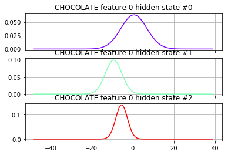

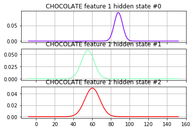

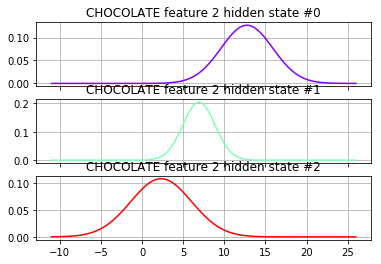

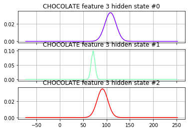

```python
import math
from matplotlib import (cm, pyplot as plt, mlab)

def visualize(word, model):
    """ visualize the input model for a particular word """
    variance=np.array([np.diag(model.covars_[i]) for i in range(model.n_components)])
    figures = []
    for parm_idx in range(len(model.means_[0])):
        xmin = int(min(model.means_[:,parm_idx]) - max(variance[:,parm_idx]))
        xmax = int(max(model.means_[:,parm_idx]) + max(variance[:,parm_idx]))
        fig, axs = plt.subplots(model.n_components, sharex=True, sharey=False)
        colours = cm.rainbow(np.linspace(0, 1, model.n_components))
        for i, (ax, colour) in enumerate(zip(axs, colours)):
            x = np.linspace(xmin, xmax, 100)
            mu = model.means_[i,parm_idx]
            sigma = math.sqrt(np.diag(model.covars_[i])[parm_idx])
            ax.plot(x, mlab.normpdf(x, mu, sigma), c=colour)
            ax.set_title("{} feature {} hidden state #{}".format(word, parm_idx, i))

            ax.grid(True)
        figures.append(plt)
    for p in figures:
        p.show()

visualize(my_testword, model)
```

##### ModelSelector class

Review the `ModelSelector` class from the codebase found in the `my_model_selectors.py` module. It is designed to be a strategy pattern for choosing different model selectors. For the project submission in this section, subclass `SelectorModel` to implement the following model selectors. In other words, you will write your own classes/functions in the `my_model_selectors.py` module and run them from this notebook:

- `SelectorCV`: Log likelihood with CV
- `SelectorBIC`: BIC
- `SelectorDIC`: DIC

You will train each word in the training set with a range of values for the number of hidden states, and then score these alternatives with the model selector, choosing the "best" according to each strategy. The simple case of training with a constant value for `n_components` can be called using the provided `SelectorConstant` subclass as follow:

```python
from my_model_selectors import SelectorConstant

training = asl.build_training(features_ground)  # Experiment here with different feature sets defined in part 1
word = 'VEGETABLE' # Experiment here with different words
model = SelectorConstant(training.get_all_sequences(), training.get_all_Xlengths(), word, n_constant=3).select()
print("Number of states trained in model for {} is {}".format(word, model.n_components))
```

```
Number of states trained in model for VEGETABLE is 3
```

##### Cross-validation folds

If we simply score the model with the Log Likelihood calculated from the feature sequences it has been trained on, we should expect that more complex models will have higher likelihoods. However, that doesn't tell us which would have a better likelihood score on unseen data. The model will likely be overfit as complexity is added. To estimate which topology model is better using only the training data, we can compare scores using cross-validation. One technique for cross-validation is to break the training set into "folds" and rotate which fold is left out of training. The "left out" fold scored. This gives us a proxy method of finding the best model to use on "unseen data". In the following example, a set of word sequences is broken into three folds using the [scikit-learn Kfold](http://scikit-learn.org/stable/modules/generated/sklearn.model_selection.KFold.html) class object. When you implement `SelectorCV`, you will use this technique.

```python
from sklearn.model_selection import KFold

training = asl.build_training(features_ground) # Experiment here with different feature sets
word = 'VEGETABLE' # Experiment here with different words
word_sequences = training.get_word_sequences(word)
split_method = KFold()
for cv_train_idx, cv_test_idx in split_method.split(word_sequences):
    print("Train fold indices:{} Test fold indices:{}".format(cv_train_idx, cv_test_idx))  # view indices of the folds
```

```
Train fold indices:[2 3 4 5] Test fold indices:[0 1]
Train fold indices:[0 1 4 5] Test fold indices:[2 3]
Train fold indices:[0 1 2 3] Test fold indices:[4 5]
```

**Tip:** In order to run `hmmlearn` training using the X,lengths tuples on the new folds, subsets must be combined based on the indices given for the folds. A helper utility has been provided in the `asl_utils` module named `combine_sequences` for this purpose.

##### Scoring models with other criterion

Scoring model topologies with **BIC** balances fit and complexity within the training set for each word. In the BIC equation, a penalty term penalizes complexity to avoid overfitting, so that it is not necessary to also use cross-validation in the selection process. There are a number of references on the internet for this criterion. These [slides](http://www2.imm.dtu.dk/courses/02433/doc/ch6_slides.pdf) include a formula you may find helpful for your implementation.

The advantages of scoring model topologies with **DIC** over BIC are presented by Alain Biem in this [reference](http://citeseerx.ist.psu.edu/viewdoc/download?doi=10.1.1.58.6208&rep=rep1&type=pdf) (also found [here](https://pdfs.semanticscholar.org/ed3d/7c4a5f607201f3848d4c02dd9ba17c791fc2.pdf)). DIC scores the discriminant ability of a training set for one word against competing words. Instead of a penalty term for complexity, it provides a penalty if model liklihoods for non-matching words are too similar to model likelihoods for the correct word in the word set.